# Homework 7

### Part c: assessing a model 5pts

Here’s a slightly more open-ended question. We *assumed* that the data followed a Poisson distribution. This may or may not be a reasonable assumption. Use any and all tools that you know to assess (either with code or simply in words) how reasonable or unreasonable this assumption is.

Once again, there are no strictly right or wrong answers here. Explain and defend your decisions and thought processes in a reasonable way and you will receive full credit.

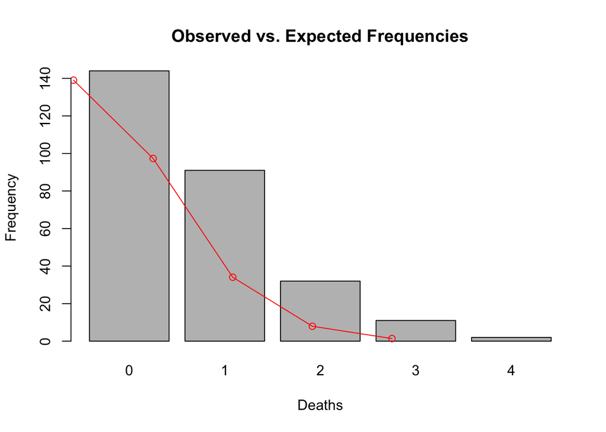

```r
library(ggplot2)

obs_freq <- table(mule_kicks$deaths)

lambdahat <- mean(mule_kicks$deaths)
deaths_seq <- 0:max(as.integer(names(obs_freq)))
expected_freq <- dpois(deaths_seq, lambdahat) * length(mule_kicks$deaths)

# Plot observed frequencies
barplot(obs_freq, names.arg = names(obs_freq), main = "Observed vs. Expected Frequencies", xlab = "Deaths", ylab = "Frequency")

# Overlay expected frequencies
lines(deaths_seq, expected_freq, col = "red", type = "o")
```

- Observing that the line representing expected frequencies closely follows the pattern of observed data suggests that the assumption of a Poisson distribution for the data is reasonable. This alignment indicates that the distribution of the number of soldiers killed by mule kicks in the Prussian army behaves consistently with the characteristics of a Poisson process, which models the occurrence of independent rare events within a fixed interval or space.

## Problem 2: Closing the loop 10 pts

In our discussion of the Universal Widgets of Madison company from lecture, we said that we were interested in two questions:

1. Estimating the probability $p$ that a widget is functional.
2. How many widgets should be in a batch to ensure that (with high probability) a batch ships with at least $5$ functional widgets in it?

We discussed question (1) at length in lecture. What about question (2)? Our client wants to know how many widgets should ship in each batch so as to ensure that the probability there are at least $5$ functional widgets in a batch is at least $0.99$.

Now, suppose that we have observed data and estimated $p$ to be $0.82$.

Use everything you know so far in this course to give a recommendation to the client. Be sure to explain clearly what you are doing and why. If there are any steps, assumptions, etc., that you are not 100% pleased with, feel free to point them out.

**Note:** there are at least two “obvious” ways to solve this problem. One is based on using Monte Carlo (i.e., assume $p=0.82$ is the truth, and try generating batches of different sizes, etc.). The other uses direct computation of probabilities, using basic facts about Binomial RVs. Neither of these is necessarily better than the other, and you do not need to use both approaches to receive full credit. Indeed, you are free to try doing something else entirely, if you wish. Just explain clearly what you are doing and why!

```r
# Assume p=0.82 is truth
phat <- 0.82
desired_prob <- 0.99
min_functional <- 5

# Function to simulate one batch
simulate_batch <- function(batch_size, p) {
  rbinom(1, batch_size, p) >= min_functional
}

# Function to estimate probability for a given batch size
estimate_prob <- function(batch_size, p, simulations = 1e4) {
  mean(replicate(simulations, simulate_batch(batch_size, p)))
}

# Find minimum batch size
batch_size <- 1
while (estimate_prob(batch_size, phat) < desired_prob) {
  batch_size <- batch_size + 1
}
batch_size
```

[output not shown]

- I use a Monte Carlo simulation method to iteratively determine the minimum batch size required to ensure that at least 5 widgets are functional with a probability of at least 99%, given a widget functionality rate of 82%. It does so by simulating the outcomes for batches of increasing size until the desired probability threshold is met, using the binomial distribution to model the number of functional widgets per batch.